# Lab 3.2: Tidyverse: Pipes and Dplyr

Statistical Computing, 36-350

Thursday July 18, 2019

**This week’s agenda**: learning to master pipes and `dplyr`.

```r
# Load the tidyverse!
library(tidyverse)
```

# Pipes to base R

For each of the following code blocks, which are written with pipes, write equivalent code in base R (to do the same thing).

- **1a.**

```r
letters %>%
  toupper %>%
  paste(collapse="+")
```

```
## [1] "A+B+C+D+E+F+G+H+I+J+K+L+M+N+O+P+Q+R+S+T+U+V+W+X+Y+Z"
```

- **1b.**

```r
"     Ceci n'est pas une pipe     " %>%
  gsub("une", "un", .) %>%
  trimws
```

```
## [1] "Ceci n'est pas un pipe"
```

- **1c.** (Still use `ggplot`)

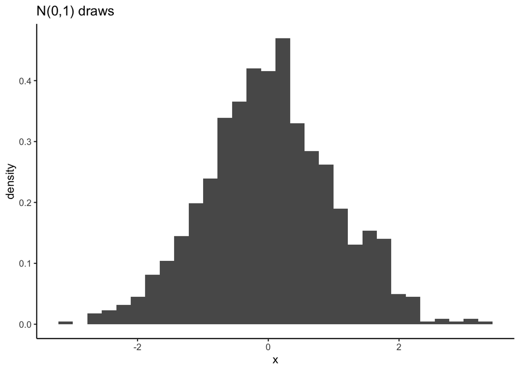

```r
rnorm(1000) %>%
  data.frame(x = .) %>%
  ggplot(.) +  # I'm giving you a hint here
    geom_histogram(aes(x = x, y = ..density..)) +
    labs(title = "N(0,1) draws")
```

- **1d.**

```r
rnorm(1000) %>%
  hist(breaks=30, plot=FALSE) %>% # use the ?hist to figure out what this does when plot=FALSE
  .[["density"]] %>%
  max
```

```
## [1] 0.405
```

# Base R to pipes

For each of the following code blocks, which are written in base R, write equivalent code with pipes (to do the same thing).

- **2a.** Hint: you’ll have to use the dot `.`, as seen above in Q1b, or in the lecture notes.

```r
paste("Your grade is", sample(c("A","B","C","D","R"), size = 1))
```

```
## [1] "Your grade is D"
```

- **2b.** Hint: you can use the dot `.` again, in order to index `state.name` directly in the last pipe command.

```r
state.name[which.max(state.x77[,"Illiteracy"])]
```

```
## [1] "Louisiana"
```

- **2c.** Hint: if `x` is a list of length 1, then `x[[1]]` is the same as `unlist(x)`.

```r
str_url <-
  paste0("https://raw.githubusercontent.com/benjaminleroy/",
         "36-350-summer-data/master/Week1/endgame.txt")

# Base R:
lines <- readLines(str_url)
text <- paste(lines, collapse = " ")
words <- strsplit(text, split = "[[:space:]]|[[:punct:]]")[[1]]
wordtab <- table(words)
wordtab <- sort(wordtab, decreasing = TRUE)
head(wordtab, 10)
```

```
## words
##         the    to     I     a   and   you     s    of    it
## 10146   780   553   478   466   408   375   374   282   261
```

- **2d.** Hint: the only difference between this and the last part is the line `words = words[words != ""]`. This is a bit tricky line to do with pipes: use the dot `.`, once more, and manipulate it as if were a variable name.

```r
# Base R:
lines <- readLines(str_url)
text <- paste(lines, collapse = " ")
words <- strsplit(text, split = "[[:space:]]|[[:punct:]]")[[1]]
words <- words[words != ""]
wordtab <- table(words)
wordtab <- sort(wordtab, decreasing = TRUE)
head(wordtab, 10)
```

```
## words
## the  to   I   a and you   s  of  it  in
## 780 553 478 466 408 375 374 282 261 251
```

# Shark attack data, revisited

Below we read in the similar data.frame `shark_attacks` containing information about victims of shark attacks we’ve seen in previous labs. (Note the difference of location - I changed it a little bit.)

```r
shark_attacks <- read.csv("https://raw.githubusercontent.com/benjaminleroy/36-350-summer-data/master/Week2/shark-attacks-clean.csv", stringsAsFactors = TRUE)
```

- **3a.** Write and document a function `time_factor_to_numeric` that transforms a time (storaged as a stringed factor) into a numerical value. Additionally, make sure that if the value is `NA`, the function returns `NA`. Use the below `my_fac` and `my_fac2` as an example of what format is expected to be inputed. Also uncomment the code below to check you function. **Reminder**: use the Roxygen2 shortcut to help document your function.

```r
time_factor_to_numeric <- function(time_fac) {
  # fill in and document
  NULL
}
```

```r
my_fac <- factor(c("13h30"))
my_fac2 <- factor(c(NA))

# my_fac_numeric <- time_factor_to_numeric(my_fac)
# my_fac_numeric == 13.5
# my_fac2_numeric <- time_factor_to_numeric(my_fac2)
# is.na(my_fac2_numeric)
```

- **3b.** Attempt your function on the factor vector `my_fac3` found below (Use the commented out code below to do so). If it doesn’t work continue to **3c.** after defining `time_factor_to_numeric_no_vec <- time_factor_to_numeric` as seen below. If your function does vectorize (i.e. passes the `all.equal` statement), define `time_factor_to_numeric_no_vec` as another function with the same structure as `time_factor_to_numeric` but use `strsplit` and see that it doesn’t vectorize.

```r
my_fac3 <- factor(c("05h15", NA, "23h59"))

#my_fac3_numeric <- time_factor_to_numeric(my_fac3)
#all.equal(my_fac3_numeric, c(5.25, NA, 23 + 59/60))
```

```r
time_factor_to_numeric_no_vec <- time_factor_to_numeric
```

- **3c.** Write a new function `time_factor_to_numeric_vec` that takes in a vector and returns a vector (use the same test as in **3b**). For this implimentation use an `sapply` and your `time_factor_to_numeric_no_vec`. Document as well.
- **3d.** In R, as you’ve seen with indexing and more, we approach of problems through a vectorized framework. Below you’ll see that we define a new function `time_factor_to_numeric_vectorized` that wraps the function `Vectorize` around your non-vectorized function. Use the same test as seen in part **3b** and **3c** to see if this function works well

```r
time_factor_to_numeric_vectorized <- Vectorize(time_factor_to_numeric_no_vec)
```

# dplyr attacks sharks

With your vectorized function we’ll start exploring the `dplyr` tools we saw in lecture.

- **4a.** Quick clean up. Convert the Time column in the `shark_attacks` to numeric using `time_factor_to_numeric_vectorized`. Hint: use `mutate_at()`, and reassign `shark_attacks` to be the output.
- **4b.** Using `dplyr`’s `mutate` function create 3 new numeric columns `year`, `month`, and `day` for the shark_attacks `data.frame` Before you do, check the `class` of the `Date` class using the dplyr pipes and the `pull` function.
- **4c.** Suppose you’re writing a story about shark attacks in the United States that were fatal. You’re interested in tracking down family of some of these individuals. Moreover, for journalistic purposes - it’s probably best that you select families based on how recently the attack happened. First, create a new data.frame `fatal_shark_attacks_usa` that contain information of all attacks in the US that were fatal.
- **4d.** Using `fatal_shark_attacks_usa` produce a table that contains individuals that meet the rest of the conditions above, and show the top 3 individuals’s `Name`, `Age`, `Area` of attack, and `year` of attack. Hint: this will use `arrange`, `select`, and `slice`. *I expect this will take some thinking - maybe pull out a piece of paper and write down the goals and try to decide how they relate to `dplyr` functions.*
- **4e.** Remembering that `ggplot` does some tabulation internally in certain `geom`s: Use `dplyr` piping and functions to explore the following question. Are there particular months of the year where its there are fewer fatal attacks than others (all countries)?
- **4f.** That seems weird. Facet the above graphic on country. Describe what you see. What is the month with the most fatal attacks in the US?
- **4g.** *Challenge:* Use the built in data vector `month.abb` to create a new column in `shark_attacks` `month_abb` that is a factor variable will the correct month associated with the attack and is ordered. Update **3f** and **3e** figures with this information. Also add `scale_x_discrete(drop = FALSE)` to your plots. What does this do?